# Chi Square Tests

```r
> shapiro.test(x)

    Shapiro-Wilk normality test

data:  x
W = 0.93145, p-value < 2.2e-16
```

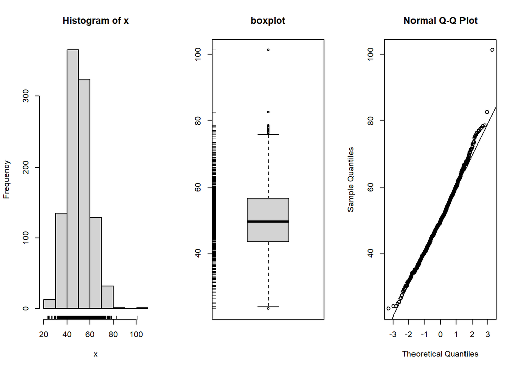

```r
> x <- rchisq(1000, 50)
> simple.eda(x)
```

```r
> shapiro.test(x)

    Shapiro-Wilk normality test

data:  x
W = 0.99206, p-value = 3.297e-05
```

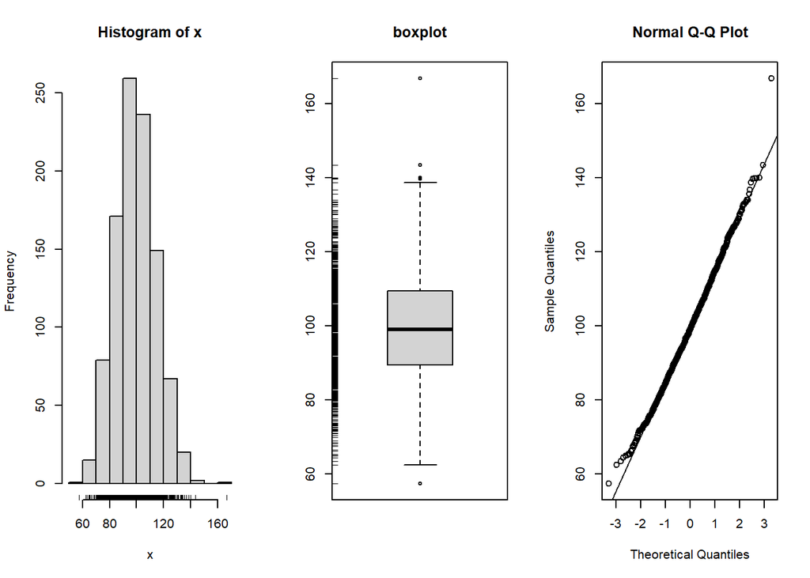

```r
> x <- rchisq(1000, 100)
> simple.eda(x)
```

```r
> shapiro.test(x)

    Shapiro-Wilk normality test

data:  x
W = 0.99639, p-value = 0.02072
```

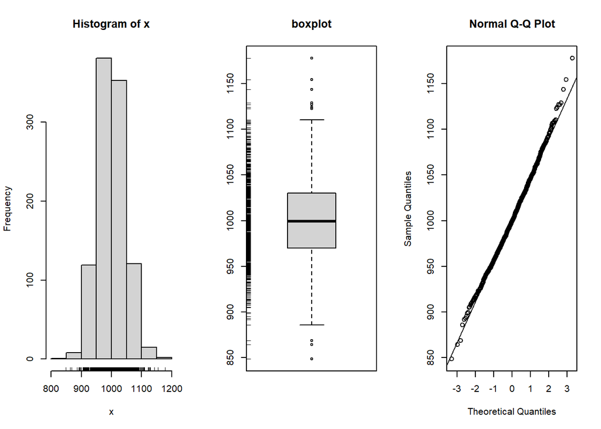

```r
> x <- rchisq(1000, 1000)
> simple.eda(x)
```

```r
> shapiro.test(x)

    Shapiro-Wilk normality test

data:  x
W = 0.99734, p-value = 0.09987
```

We observe that when the degrees of freedom are large enough the difference between $\chi^2$ distribution and the normal one are not statistically significant.

## Chi-squared Goodness of Fit Tests

**Goodness of fit tests** check if the data come from some specific population. These tests are based on asymptotic theorems, therefore, they work better with large samples.

The **chi-squared goodness of fit tests** allows us to check if data come from a distribution described in $H_0$. As far as if this distribution is continuous we have better tests. The **chi-squared goodness of fit tests** are useful mainly if we compare empirical and discrete theoretical distribution. Moreover as far as the possible values of the observed random variable does not participate in the computations these tests are applicable also on categorical observed variables. Actually it reduces to the test that the observed distribution is **multivariate binomial** or the so, called **multinomial distribution**.

The tested hypothesis is

$H_0$ : The observed distribution coincides with

| Possible values | Category 1 | Category 2 | … | Category k | Total |
| --- | --- | --- | --- | --- | --- |
| Theoretical probability | $p_1$ | $p_2$ | … | $p_k$ | 1 |

If the sample size is $n$, then the number of observations $\nu_i$ in the $i$-th group, given $H_0$ would be $(\nu_i|H_0) \in Bi(n, p_i)$, $i = 1, 2, ..., k$. Therefore, the expected number of observations in each group, given $H_0$ would be

| Possible values | Category 1 | Category 2 | … | Category k | Total |
| --- | --- | --- | --- | --- | --- |
| $E(\nu_i\|H_0)$ | $np_1$ | $np_2$ | … | $np_k$ | n |

The expected count of category $i$ according to $H_0$ is usually denoted by $e_i = np_i$, $i = 1, 2, \ldots, k$.

Let us suppose that the tested distribution in $H_0$ has $r$ unknown parameters estimated from the sample.

The alternative is usually one-sided although when the number of groups is large enough two-sided alternatives are also possible.

$H_A$: The observed distribution does not coincide with this theoretical one.

We chose level of significance $\alpha$.

As a measure of discrepancy between the observed and the theoretical distribution described in $H_0$, this test uses the statistics

$$\sum_{i = 1}^k \frac{(\nu_i - np_i)^2}{np_i}.$$
If the data is i.i.d., if $H_0$ is correct, if the sample is large enough, if for all $i = 1, 2, ..., k$, $np_i \geq 1$ (as far as we can not divide to $0$) and if 80% of $np_i$, $i = 1, 2, ..., k$ are bigger than $5$, then,

$$\left(\sum_{i = 1}^k \frac{(\nu_i - np_i)^2}{np_i}\left| H_0 \right. \right) \stackrel{d}{\to} \chi(k - r - 1).$$
Therefore, if the sample is large enough the one sided critical area is
$$W_\alpha = \left\{\sum_{i = 1}^k \frac{(\nu_i - np_i)^2}{np_i} \geq x_{1-\alpha, \chi^2(k-r-1)}\right\},$$

### Example 1

John have tossed a die 150 times and found that it has the following distribution

| Face | 1 | 2 | 3 | 4 | 5 | 6 |
| --- | --- | --- | --- | --- | --- | --- |
| Number of rolls | 22 | 21 | 22 | 27 | 22 | 36 |

Help him to check if the die is regular.

If the dice is regular then we would expect the six categories (faces) to have the same chance to happen.

In $n = 150$ rolls we would expect each face to have about $(\nu_i|H_0) \in Bi(n, \frac{1}{6})$. Therefore,

$H_0$ : The observed distribution coincides with

| Possible values | Category 1 | Category 2 | … | Category 6 | Total |
| --- | --- | --- | --- | --- | --- |
| Theoretical probability | $\frac{1}{6}$ | $\frac{1}{6}$ | … | $\frac{1}{6}$ | 1 |

and the expected number of observations in each group, given $H_0$ would be

| Possible values | Category 1 | Category 2 | … | Category 6 | Total |
| --- | --- | --- | --- | --- | --- |
| $E(\nu_i\|H_0)$ | $np_1 = \frac{150}{6}$ | $np_2= \frac{150}{6}$ | … | $np_6 = \frac{150}{6}$ | $n = 150$ |

```r
> 150/6
[1] 25
```

25 appearances.

| Possible values | Category 1 | Category 2 | … | Category 6 | Total |
| --- | --- | --- | --- | --- | --- |
| $E(\nu_i\|H_0)$ | 25 | 25 | … | 25 | n = 150 |

John obtains $6$ points $36$ times. Is this coincidence or perhaps something else?

The answer to this question is to look at **how far off the data is from the expected**. We denote by

$f_i$ - the observed frequency of category $i$ in the sample and by

$e_i = np_i$ - the expected count of category $i$ according to $H_0$.

$H_0: p_i = \frac{1}{6}, \quad i = 1, 2, 3, 4, 5, 6$

$H_A: \exists i : p_i \neq \frac{1}{6}, \quad i = 1, 2, 3, 4, 5, 6$

In our case $k = 6$. The sample size is $n = 150$ - relatively large. We have not estimated parameters of the distribution in $H_0$ from the sample, therefore $r = 0$. The data is i.i.d., the conditions $\nu_i \geq 1$, $i = 1, 2, \ldots, k$, and the one to have at least $80\%$ of $\nu$ to be bigger than $5$ are satisfied.

Therefore,

$$W_\alpha = \left\{\sum_{i = 1}^6 \frac{(\nu_i - 25)^2}{25} \geq x_{1-\alpha, \chi^2(6-0-1)}\right\},$$

Now we chose $\alpha = 0,05$ and compute $x_{1-\alpha, \chi^2(5)} = 11.0705$.

```r
> qchisq(0.95,5)
[1] 11.0705
```

Therefore,
$$W_\alpha = \left\{\sum_{i = 1}^6 \frac{(\nu_i - 25)^2}{25} \geq 11.0705\right\},$$
Now we can check if the sample is in the critical area $W_\alpha$ for $H_0$. Therefore, we replace the random variables $\nu_i$, $i = 1, 2, \ldots, 6$ correspondingly with $f_1, f_2, ..., f_6$ observed in the sample

$$x_{emp} = \sum_{i = 1}^6 \frac{(f_i - 25)^2}{25}$$

$$= \frac{(22 - 25)^2}{25}+\frac{(21 - 25)^2}{25}+\frac{(22 - 25)^2}{25}+\frac{(27 - 25)^2}{25}+\frac{(22 - 25)^2}{25}+\frac{(36 - 25)^2}{25} = 6.72$$

```r
> f <- c(22, 21, 22, 27, 22, 36)
> e <- sum(f) * 1/6
> xemp <- sum((f-e)^2/e); xemp
[1] 6.72
```

Now, we compare $x_{emp} = 6.72$ with $x_{1-\alpha, \chi^2(5)} = 11.0705$

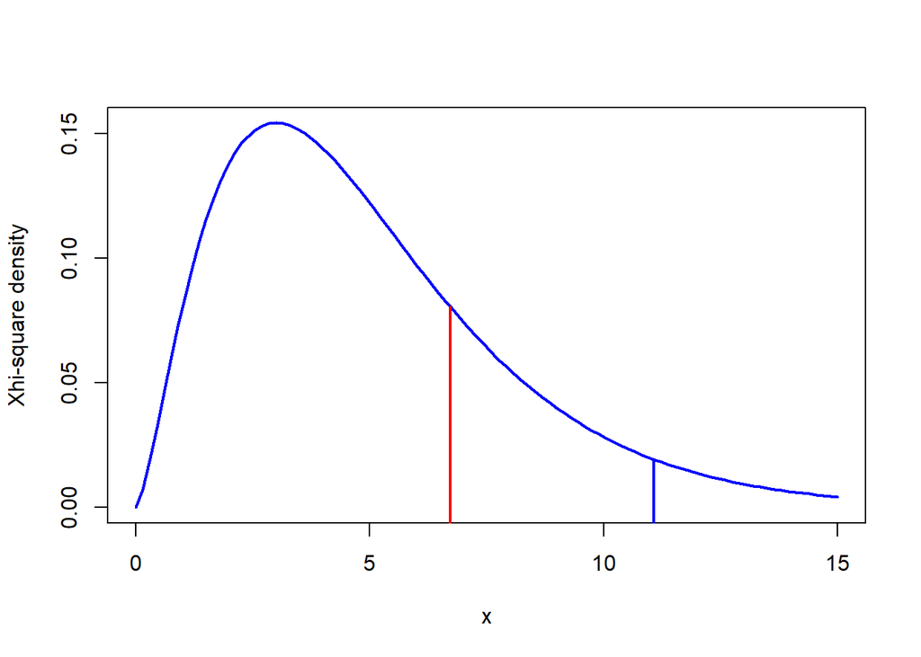

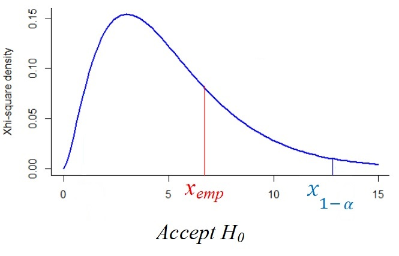

```r
> df <- length(f) - 1
> alpha <- 0.05
> curve(dchisq(x, df), from = 0, to = 15, col = "blue", lwd = 2, ylab = "Xhi-square density")
> x <- qchisq(1 - alpha, df)
> segments(x, -1, x, dchisq(x, df), col = "blue", lwd = 2)
> segments(xemp, -1, xemp, dchisq(xemp, df), col = "red", lwd = 2)
```

and conclude that the sample is not in the critical area for $H_0$. Therefore, we have no evidence to reject $H_0$.

Another way to make the same conclusion is via the $p-value$. It is the probability of the event that a $\chi^2$ random variable having $5$ df is bigger than $x_{emp}$
$$P\left(\sum_{i = 1}^6 \frac{(\nu_i - 25)^2}{25} > x_{emp}\right) = P(\eta > 6.72) \approx 0.2423, \quad \eta \in \chi^2(5).$$

```r
> pchisq(xemp, df, lower.tail = FALSE)
[1] 0.2423109
```

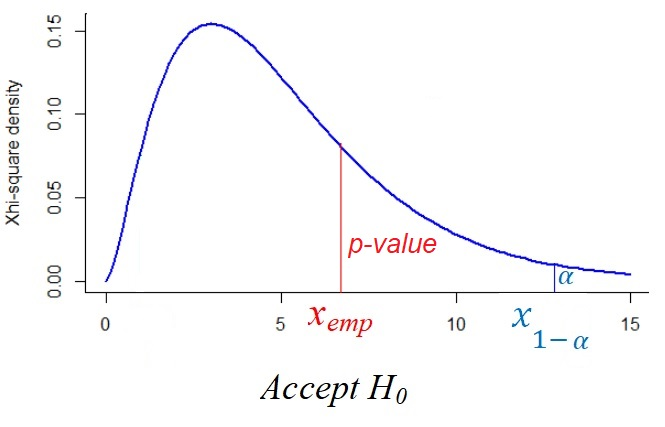

The $p-value = 0.2423109 > 0.05 = \alpha$, so we have no evidence to reject $H_0$.

The easiest way to make the same (only in cases when the alternative is once sided) is to use the build in function `chisq.test`

```r
> freq <- c(22, 21, 22, 27, 22, 36)
> prob <- rep(1/6, 6)
> chisq.test(freq, p = prob)

    Chi-squared test for given probabilities

data:  freq
X-squared = 6.72, df = 5, p-value = 0.2423
```

The $p-value = 0.2423 > 0.05 = \alpha$, so we have no evidence to reject $H_0$. We can assume that the die is fair. The $X-squared = x_{emp} = 6.72$ and $df = 5$.

### Example 2

Let us now suppose that we have the original data (not only the frequencies in the groups). More precisely in order to trow a fair die $150$ times let us generate $150$ observations on a Discrete Uniform random variable variable.

```r
> set.seed(1)
> y <- sample(1:6, 150, replace = TRUE)
> freq <- table(y); freq
y
 1  2  3  4  5  6
28 25 23 23 22 29
```

$H_0$ : The observed distribution coincides with

| Possible values | Category 1 | Category 2 | … | Category 6 | Total |
| --- | --- | --- | --- | --- | --- |
| Theoretical probability | $\frac{1}{6}$ | $\frac{1}{6}$ | … | $\frac{1}{6}$ | 1 |

and the expected number of observations in each group, given $H_0$ would be

| Possible values | Category 1 | Category 2 | … | Category 6 | Total |
| --- | --- | --- | --- | --- | --- |
| $E(\nu_i\|H_0)$ | $np_1 = \frac{150}{6}$ | $np_2= \frac{150}{6}$ | … | $np_6 = \frac{150}{6}$ | $n = 150$ |

```r
> 150/6
[1] 25
```

25 appearances.

| Possible values | Category 1 | Category 2 | … | Category 6 | Total |
| --- | --- | --- | --- | --- | --- |
| $E(\nu_i\|H_0)$ | 25 | 25 | … | 25 | n = 150 |

$H_A: \exists i : p_i \neq \frac{1}{6}, \quad i = 1, 2, 3, 4, 5, 6$

Again $k = 6$, the sample size is $n = 150$. We assume that it is large. We have not estimated parameters of the distribution in $H_0$ from the sample, therefore $r = 0$. The data is i.i.d., the conditions $\nu_i \geq 1$, $i = 1, 2, \ldots, k$, and the one to have at least $80\%$ of $\nu$ to be bigger than $5$ are satisfied.

Therefore,

$$W_\alpha = \left\{\sum_{i = 1}^6 \frac{(\nu_i - 25)^2}{25} \geq x_{1-\alpha, \chi^2(6-0-1)}\right\},$$

Now we chose $\alpha = 0,05$ and compute $x_{1-\alpha, \chi^2(5)} = 11.0705$.

```r
> qchisq(0.95,5)
[1] 11.0705
```

Therefore, the critical area is the same
$$W_\alpha = \{\sum_{i = 1}^6 \frac{(\nu_i - 25)^2}{25} \geq 11.0705\},$$
Now we can check if the sample is in the critical area $W_\alpha$ for $H_0$. Therefore, we replace the random variables $\nu_i$, $i = 1, 2, \ldots, 6$ correspondingly with $f_1, f_2, ..., f_6$ observed in the sample

$$x_{emp} = \sum_{i = 1}^6 \frac{(f_i - 25)^2}{25}$$

$$= \frac{(28 - 25)^2}{25}+\frac{(25 - 25)^2}{25}+\frac{(23 - 25)^2}{25}+\frac{(23 - 25)^2}{25}+\frac{(22 - 25)^2}{25}+\frac{(29 - 25)^2}{25} = 1.68$$

```r
> f <- c(28, 25, 23, 23, 22, 29)
> e <- sum(f) * 1/6
> xemp <- sum((f-e)^2/e); xemp
[1] 1.68
```

Now, we compare $x_{emp} = 1.68$ with $x_{1-\alpha, \chi^2(5)} = 11.0705$

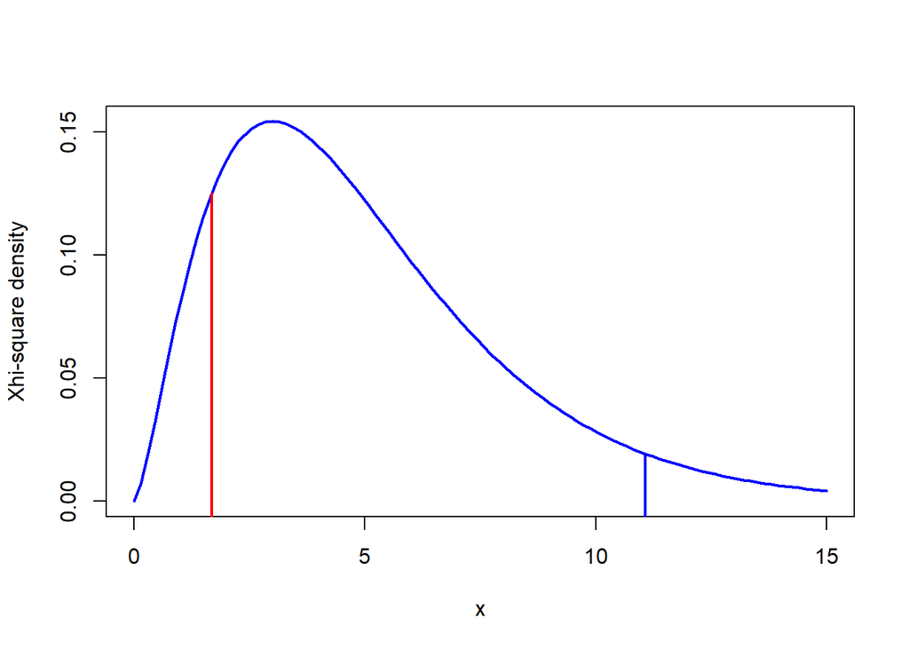

```r
> df <- length(f) - 1
> alpha <- 0.05
> curve(dchisq(x, df), from = 0, to = 15, col = "blue", lwd = 2, ylab = "Xhi-square density")
> x <- qchisq(1 - alpha, df)
> segments(x, -1, x, dchisq(x, df), col = "blue", lwd = 2)
> segments(xemp, -1, xemp, dchisq(xemp, df), col = "red", lwd = 2)
```

and conclude that the sample is not in the critical area for $H_0$. Therefore, we have no evidence to reject $H_0$.

The $p-value$ is the probability of the event that a $\chi^2$ random variable having $5$ df is bigger than $x_{emp}$
$$P\left(\sum_{i = 1}^6 \frac{(\nu_i - 25)^2}{25} > x_{emp}\right) = P(\eta > 1.68) \approx 0.8914097, \quad \eta \in \chi^2(5).$$

```r
> pchisq(xemp, df, lower.tail = FALSE)
[1] 0.8914097
```

The $p-value = 0.8914097 > 0.05 = \alpha$, so we have no evidence to reject $H_0$.

Let us now use the `chisq.test` function

```r
> f <- c(28, 25, 23, 23, 22, 29)
> prob <- rep(1/6, 6)
> chisq.test(f, p = prob)

    Chi-squared test for given probabilities

data:  f
X-squared = 1.68, df = 5, p-value = 0.8914
```

The $p-value = 0.8914 > 0.05 = \alpha$, so we have no evidence to reject $H_0$. We can assume that the die is fair. The $X-squared = x_{emp} = 1.68$ and $df = 5$.

### Example 3 (The sample size is not large enough)

Let’s try with different frequencies. The last means that John trows an unfair die $150$ times. In order to see the results let us generate $150$ observations on a Discrete Uniform random variable with probability mass function

| Possible values | 1 | 2 | 3 | 4 | 5 | 6 | Total |
| --- | --- | --- | --- | --- | --- | --- | --- |
| Theoretical probability | $\frac{0.75}{6}$ | $\frac{0.75}{6}$ | $\frac{1}{6}$ | $\frac{1}{6}$ | $\frac{1.25}{6}$ | $\frac{1.25}{6}$ | 1 |

and to see the performance of the same test.

```r
> set.seed(1)
> y <- sample(1:6, 150, replace = TRUE,
+             prob = c(0.75, 0.75, 1, 1, 1.25, 1.25)/6)
> freq <- table(y); freq
y
 1  2  3  4  5  6
16 19 27 30 26 32
> probs <- c(1, 1, 1, 1, 1, 1)/6
```

We formulate the same

$H_0$ : The observed distribution coincides with

| Possible values | Category 1 | Category 2 | … | Category 6 | Total |
| --- | --- | --- | --- | --- | --- |
| Theoretical probability | $\frac{1}{6}$ | $\frac{1}{6}$ | … | $\frac{1}{6}$ | 1 |

and the expected number of observations in each group, given $H_0$ would be

| Possible values | Category 1 | Category 2 | … | Category 6 | Total |
| --- | --- | --- | --- | --- | --- |
| $E(\nu_i\|H_0)$ | $np_1 = \frac{150}{6}$ | $np_2= \frac{150}{6}$ | … | $np_6 = \frac{150}{6}$ | $n = 150$ |

```r
> 150/6
[1] 25
```

25 appearances.

| Possible values | Category 1 | Category 2 | … | Category 6 | Total |
| --- | --- | --- | --- | --- | --- |
| $E(\nu_i\|H_0)$ | 25 | 25 | … | 25 | n = 150 |

$H_A: \exists i : p_i \neq \frac{1}{6}, \quad i = 1, 2, 3, 4, 5, 6$

Again $k = 6$, the sample size is $n = 150$. We assume that it is large. We have not estimated parameters of the distribution in $H_0$ from the sample, therefore $r = 0$. The data is i.i.d., the conditions $\nu_i \geq 1$, $i = 1, 2, \ldots, k$, and the one to have at least $80\%$ of $\nu$ to be bigger than $5$ are satisfied.

Therefore,

$$W_\alpha = \left\{\sum_{i = 1}^6 \frac{(\nu_i - 25)^2}{25} \geq x_{1-\alpha, \chi^2(6-0-1)}\right\},$$

Now we chose $\alpha = 0,05$ and compute $x_{1-\alpha, \chi^2(5)} = 11.0705$.

```r
> qchisq(0.95,5)
[1] 11.0705
```

Therefore, the critical area is the same
$$W_\alpha = \left\{\sum_{i = 1}^6 \frac{(\nu_i - 25)^2}{25} \geq 11.0705\right\},$$
Now we can check if the sample is in the critical area $W_\alpha$ for $H_0$. Therefore, we replace the random variables $\nu_i$, $i = 1, 2, \ldots, 6$ correspondingly with $f_1, f_2, ..., f_6$ observed in the sample

$$x_{emp} = \sum_{i = 1}^6 \frac{(f_i - 25)^2}{25}$$

$$= \frac{(16 - 25)^2}{25}+\frac{(19 - 25)^2}{25}+\frac{(27 - 25)^2}{25}+\frac{(30 - 25)^2}{25}+\frac{(26 - 25)^2}{25}+\frac{(32 - 25)^2}{25} = 7.84$$

```r
> f <- c(16, 19, 27, 30, 26, 32)
> e <- sum(f) * 1/6
> xemp <- sum((f - e)^2 / e); xemp
[1] 7.84
```

Now, we compare $x_{emp} = 7.84$ with $x_{1-\alpha, \chi^2(5)} = 11.0705$

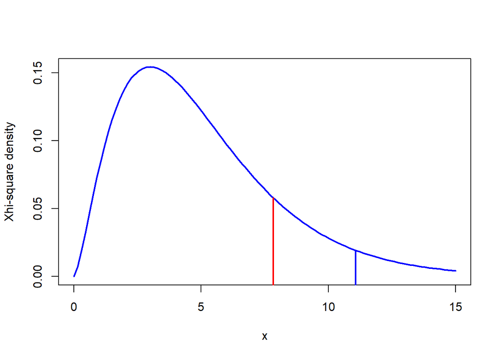

```r
> df <- length(f) - 1
> alpha <- 0.05
> curve(dchisq(x, df), from = 0, to = 15, col = "blue", lwd = 2, ylab = "Xhi-square density")
> x <- qchisq(1 - alpha, df)
> segments(x, -1, x, dchisq(x, df), col = "blue", lwd = 2)
> segments(xemp, -1, xemp, dchisq(xemp, df), col = "red", lwd = 2)
```

and conclude that the sample is not in the critical area for $H_0$. Therefore, we have no evidence to reject $H_0$.

Here we observe that when the sample size is not large enough we can obtain wrong results.

From computational point of view we can proceed further on. The $p-value$ is the probability of the event that a $\chi^2$ random variable having $5$ df is greater than $x_{emp}$
$$P\left(\sum_{i = 1}^6 \frac{(\nu_i - 25)^2}{25} > x_{emp}\right) = P(\eta > 7.84) \approx 0.1652768, \quad \eta \in \chi^2(5).$$

```r
> pchisq(xemp, df, lower.tail = FALSE)
[1] 0.1652768
```

The $p-value = 0.1652768 > 0.05 = \alpha$, so we have no evidence to reject $H_0$.

Let us now use the `chisq.test` function

```r
> f <- c(16, 19, 27, 30, 26, 32)
> prob <- rep(1/6, 6)
> chisq.test(f, p = prob)

    Chi-squared test for given probabilities

data:  f
X-squared = 7.84, df = 5, p-value = 0.1653
```

The $p-value = 0.1653 > 0.05 = \alpha$, so we have no evidence to reject $H_0$. We can assume that the die is fair. The $X-squared = x_{emp} = 7.84$ and $df = 5$.

### Example 4

Let’s us now increase the sample size. Suppose that John trows an unfair die $1500$ times. In order to see the results let us generate $1500$ observations on a Discrete Uniform random variable with probability mass function

| Possible values | 1 | 2 | 3 | 4 | 5 | 6 | Total |
| --- | --- | --- | --- | --- | --- | --- | --- |
| Theoretical probability | $\frac{0.75}{6}$ | $\frac{0.75}{6}$ | $\frac{1}{6}$ | $\frac{1}{6}$ | $\frac{1.25}{6}$ | $\frac{1.25}{6}$ | 1 |

and to see the performance of the same test.

```r
> set.seed(1)
> y <- sample(1:6, 1500, replace = TRUE,
+             prob = c(0.75, 0.75, 1, 1, 1.25, 1.25)/6)
> freq <- table(y); freq
y
  1   2   3   4   5   6
192 178 242 232 326 330
```

We formulate the same

$H_0$ : The observed distribution coincides with

| Possible values | Category 1 | Category 2 | … | Category 6 | Total |
| --- | --- | --- | --- | --- | --- |
| Theoretical probability | $\frac{1}{6}$ | $\frac{1}{6}$ | … | $\frac{1}{6}$ | 1 |

and the expected number of observations in each group, given $H_0$ would be

| Possible values | Category 1 | Category 2 | … | Category 6 | Total |
| --- | --- | --- | --- | --- | --- |
| $E(\nu_i\|H_0)$ | $np_1 = \frac{1500}{6}$ | $np_2= \frac{1500}{6}$ | … | $np_6 = \frac{1500}{6}$ | $n = 1500$ |

```r
> 150/6
[1] 25
```

| Possible values | Category 1 | Category 2 | … | Category 6 | Total |
| --- | --- | --- | --- | --- | --- |
| $E(\nu_i\|H_0)$ | 250 | 250 | … | 250 | n = 1500 |

$H_A: \exists i : p_i \neq \frac{1}{6}, \quad i = 1, 2, 3, 4, 5, 6$

Again $k = 6$, the sample size is $n = 1500$. We assume that it is large. We have not estimated parameters of the distribution in $H_0$ from the sample, therefore $r = 0$. The data is i.i.d., the conditions $\nu_i \geq 1$, $i = 1, 2, \ldots, k$, and the one to have at least $80\%$ of $\nu$ to be bigger than $5$ are satisfied.

Therefore,

$$W_\alpha = \left\{\sum_{i = 1}^6 \frac{(\nu_i - 250)^2}{250} \geq x_{1-\alpha, \chi^2(6-0-1)}\right\},$$

Now we chose $\alpha = 0,05$ and compute $x_{1-\alpha, \chi^2(5)} = 11.0705$.

```r
> qchisq(0.95, 5)
[1] 11.0705
```

Therefore, the critical area is the same
$$W_\alpha = \left\{\sum_{i = 1}^6 \frac{(\nu_i - 250)^2}{250} \geq 11.0705\right\},$$
Now we can check if the sample is in the critical area $W_\alpha$ for $H_0$. Therefore, we replace the random variables $\nu_i$, $i = 1, 2, \ldots, 6$ correspondingly with $f_1, f_2, ..., f_6$ observed in the sample

$$x_{emp} = \sum_{i = 1}^6 \frac{(f_i - 250)^2}{250}$$

$$= \frac{(192 - 250)^2}{250}+\frac{(178 - 250)^2}{250}+\frac{(242 - 250)^2}{250}+\frac{(232 - 250)^2}{250}+\frac{(326 - 250)^2}{250}+\frac{(330 - 250)^2}{250} = 84.448$$

```r
> f <- c(192, 178, 242, 232, 326, 330)
> e <- sum(f) * 1/6
> xemp <- sum((f-e)^2/e); xemp
[1] 84.448
```

Now, we compare $x_{emp} = 84.448$ with $x_{1-\alpha, \chi^2(5)} = 11.0705$

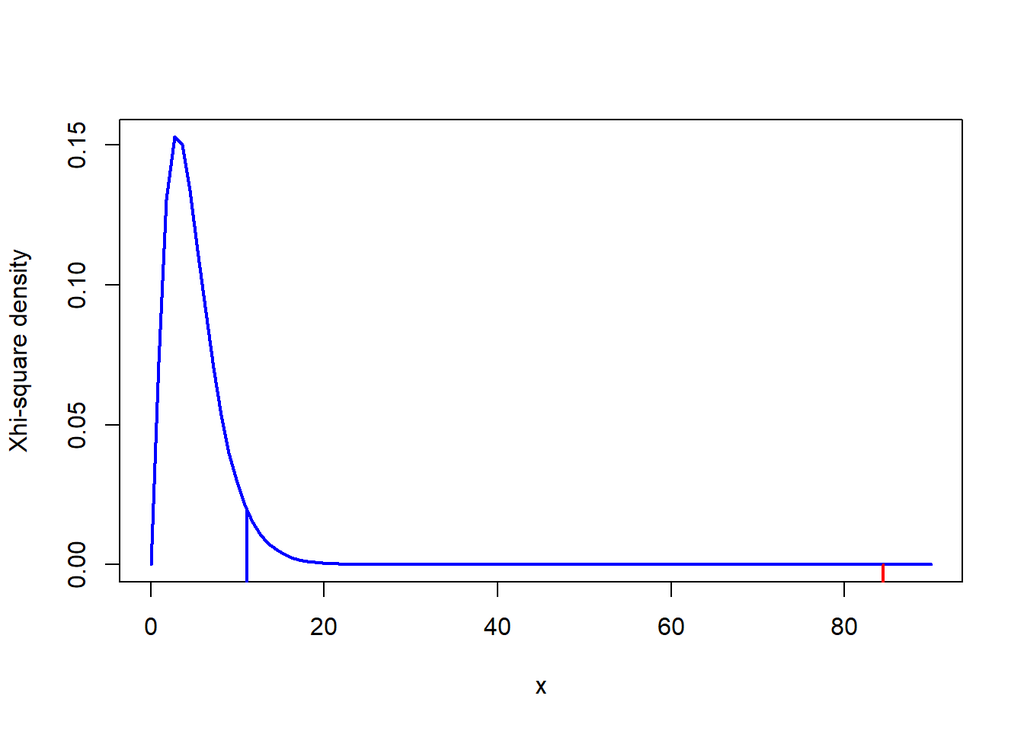

```r
> df <- length(f) - 1
> alpha <- 0.05
> curve(dchisq(x, df), from = 0, to = 90, col = "blue",lwd=2, ylab="Xhi-square density")
> x <- qchisq(1 - alpha, df)
> segments(x, -1, x, dchisq(x, df), col = "blue", lwd = 2)
> segments(xemp, -1, xemp, dchisq(xemp, df), col = "red", lwd = 2)
```

and conclude that the sample is in the critical area for $H_0$. Therefore, we reject $H_0$. Now the result is correct as far as the sample size is already large enough.

The $p-value$ is the probability of the event that a $\chi^2$ random variable having $5$ df is greater than $x_{emp}$
$$P\left(\sum_{i = 1}^6 \frac{(\nu_i - 250)^2}{250} > x_{emp}\right) = P(\eta > 84.448) \approx 9.826244* 10^{-17}, \quad \eta \in \chi^2(5).$$

```r
> pchisq(xemp, df, lower.tail = FALSE)
[1] 9.826244e-17
```

The $p-value = 9.826244 * 10^{-17} < 0.05 = \alpha$, so we reject $H_0$.

Let us now use the build in function `chisq.test`

```r
> f <- c(192, 178, 242, 232, 326, 330)
> prob <- rep(1/6, 6)
> chisq.test(f, p = prob)

    Chi-squared test for given probabilities

data:  f
X-squared = 84.448, df = 5, p-value < 2.2e-16
```

The $p-value < 2.2e-16 < 0.05 = \alpha$, so we reject $H_0$. We cannot assume that the die is fair. The $X-squared = x_{emp} = 84.448$ and $df = 5$.

### Example 5

Company printed baseball cards. It claimed that:

- $30\%$ of its cards were rookies;
- $60\%$ were veterans but not All-Stars;
- and $10\%$ were veteran All-Stars.

Random sample is taken of $100$ cards:

- $50$ of the cards were rookies;
- $45$ were veterans but not All-Stars;
- and $5$ were veteran All-Stars.

See whether our sample distribution differed statistically significantly from the distribution claimed by the company? Use significance level $0.05$.

We formulate

$H_0$ : The observed distribution coincides with

| Possible values | rookies | veterans but not All-Stars | veteran All-Stars | Total |
| --- | --- | --- | --- | --- |
| Theoretical probability | 0.3 | 0.6 | 0.1 | 1 |

and the expected number of observations in each group, given $H_0$ would be

| Possible values | rookies | veterans but not All-Stars | veteran All-Stars | Total |
| --- | --- | --- | --- | --- |
| $E(\nu_i\|H_0)$ | $np_1=100*0.3=30$ | $np_2= 60$ | $np_3 = 10$ | $n = 100$ |

$H_A:$ There exists statistically significant difference between tested and the observed distribution.

Now $k = 3$, the sample size is $n = 100$. We assume that it is large. We have not estimated parameters of the distribution in $H_0$ from the sample, therefore $r = 0$. The data is i.i.d., the conditions $\nu_i \geq 1,\ i = 1, 2, 3$, and the one to have at least $80\%$ of $\nu$ to be bigger than $5$ are satisfied.

Therefore,

$$W_\alpha = \left\{\sum_{i = 1}^3 \frac{(\nu_i - np_i)^2}{np_i} \geq x_{1-\alpha, \chi^2(3-0-1)}\right\},$$

Now we chose $\alpha = 0,05$ and compute $x_{1-\alpha, \chi^2(2)} = 5.991465$.

```r
> qchisq(0.95,2)
[1] 5.991465
```

Therefore, the critical area is
$$W_\alpha = \left\{\sum_{i = 1}^3 \frac{(\nu_i - np_i)^2}{np_i} \geq 5.991465\right\},$$
Now we can check if the sample is in the critical area $W_\alpha$ for $H_0$. Therefore, we replace the random variables $\nu_i,\ i = 1,2,3$ correspondingly with $f_1, f_2, f_3$ observed in the sample

$$x_{emp} = \sum_{i = 1}^3 \frac{(f_i - np_i)^2}{np_i}$$

$$= \frac{(50 - 30)^2}{30}+\frac{(45 - 60)^2}{60}+\frac{(5 - 10)^2}{10} = 19.58333$$

```r
> f <- c(50, 45, 5)
> e <- c(30, 60, 10)
> xemp <- sum((f - e)^2 / e)
> xemp
[1] 19.58333
```

Now, we compare $x_{emp} = 19.58333$ with $x_{1-\alpha, \chi^2(2)} = 5.991465$

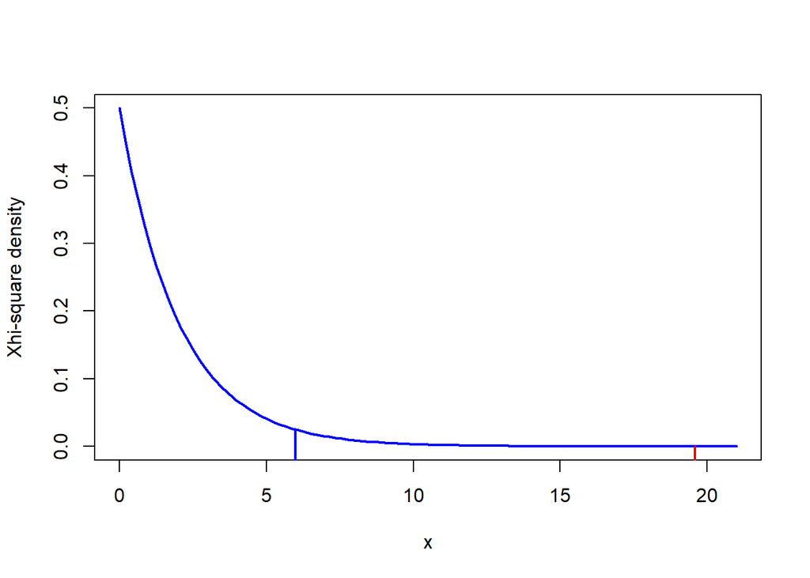

```r
> df <- length(f) - 1
> alpha <- 0.05
> curve(dchisq(x, df), from = 0, to = 21, col = "blue", lwd = 2, ylab = "Xhi-square density")
> x <- qchisq(1 - alpha, df)
> segments(x, -1, x, dchisq(x, df), col = "blue", lwd = 2)
> segments(xemp, -1, xemp, dchisq(xemp, df), col = "red", lwd = 2)
```

and conclude that the sample is in the critical area for $H_0$. Therefore, we reject $H_0$.

```r
> pchisq(xemp, df, lower.tail = FALSE)
[1] 5.591563e-05
```

The $p-value = 5.591563* 10^{-5} < 0.05 = \alpha$, so we reject $H_0$.

Let us now use the `chisq.test` function

```r
> f <- c(50,45,5)
> prob <- c(30,60,10)/100
> chisq.test(f, p = prob)

    Chi-squared test for given probabilities

data:  f
X-squared = 19.583, df = 2, p-value = 5.592e-05
```

The $p-value = 5.592e-05 < 0.05 = \alpha$, so we reject $H_0$. We cannot say that the company is correct. The sample distribution differed statistically significantly from the distribution claimed by the company.

### Example 6

Letter distribution.

The $6$ most popular letters in the English language are $E$, $T$, $A$, $N$, $R$, $O$ and their frequencies are:

- $E$ - $12\%$
- $T$ - $9\%$
- $A$ - $8\%$
- $N$ - $7\%$
- $R$ - $7\%$
- $O$ - $7\%$
- $Another$ - $50\%$

A text is analyzed and the number of $E$, $T$, $A$, $N$, $R$, $O$’s and others are counted:

- $E$ - $100$
- $T$ - $110$
- $A$ - $90$
- $N$ - $80$
- $R$ - $55$
- $O$ - $14$
- $Another$ - $600$.

Is this text from the English language?

$H_0:\ p_E = 0.12,\ p_T = 0.09,\ p_A = 0.08,\ p_N = 0.07,\ p_R = 0.07,\ p_O = 0.07,\ p_{Another} = 0.5$

According to $H_0$ the text is written in English. The differences between the theoretical and empirical frequencies are not statistically significant.

$H_A$: At least one category doesn’t have this specified probability.

Note: chi-squared test requires independence of each letter, so this is not quite appropriate, but let’s suppose the letters are independent.

```r
> f <- c(100, 110, 90, 80, 55, 14, 600)
> probs = c(12, 9, 8, 7, 7, 7, 50) / 100
> chisq.test(f, p = probs)

    Chi-squared test for given probabilities

data:  f
X-squared = 72.516, df = 6, p-value = 1.245e-13
```

$p-value = 1.245*10^{-13} < 0.05 = \alpha$, so we reject $H_0$. The text is not written in English. The differences between the theoretical and empirical frequencies are statistically significant.

### Example 7

The $6$ most popular letters in the English language are $E$, $T$, $A$, $N$, $R$, $O$ and as we see their frequencies are:

- $E$ - $12\%$
- $T$ - $9\%$
- $A$ - $8\%$
- $N$ - $7\%$
- $R$ - $7\%$
- $O$ - $7\%$
- $Another$ - $50\%$

Take some part from Verzani and calculate the number of appearances of $E$, $T$, $A$, $N$, $R$, $O$ and the number of other characters. You can use this [site](http://www.countcalculate.com/everyday-life/count-characters-and-words-in-text). By using $\chi^2$ test check if this text is an English text.

Let us consider page $8$, the text in Section $3$ before the title “Categorical data”.

According to the above letter count calculator the total number of characters is $n = 1 671$, where:

- $E - 215$
- $T - 165$
- $A - 149$
- $N - 103$
- $R - 100$
- $O - 113$
- $Another - 826$

The hypothesis are the same $H_0:\ p_E = 0.12,\ p_T = 0.09,\ p_A = 0.08,\ p_N = 0.07,\ p_R = 0.07,\ p_O = 0.07,\ p_{Another} = 0.50$

According to $H_0$ the text is written in English. The differences between the theoretical and empirical frequencies are not statistically significant.

$H_A$: At least one category doesn’t have this specified probability.

```r
> f <- c(215, 165, 149, 103, 100, 113, 826);
> probs = c(12, 9, 8, 7, 7, 7, 50) / 100
> chisq.test(f, p = probs)

    Chi-squared test for given probabilities

data:  f
X-squared = 8.5939, df = 6, p-value = 0.1977
```

The $p-value = 0.1977 > 0.05 = \alpha$. We have no evidence to reject $H_0$. The text is written in English. The differences between the theoretical and empirical frequencies are not statistically significant.

### Example 8

There are sewing machines in an industrial unit. Everyday at $6$ o’clock the machines are checked and the number of the machines that have to be repaired is determined. The manufacturer has observed $450$ days. The results from the observation are given in the following table.

| The number of damiged machines | The number of days |
| --- | --- |
| 0 | 149 |
| 1 | 141 |
| 2 | 74 |
| 3 | 37 |
| 4 | 32 |
| More | 15 |

By using the $\chi^2$ test check if the observed random variable is **Poisson distributed**.

The Poisson distribution have one **parameter**. It is its **mean**. Therefore, we are going to estimate the parameter $\lambda$ via the average of the damaged sewing machines within a day.

In order to compute the mean we replace “more” with $5$.

```r
> n <- 450
> x <- c(0:5)
> f <- c(149, 141, 74, 37, 32, 15)
> lambda <- sum(x * f) / n
> lambda
[1] 1.34
```

On average there are $1.34$ damaged machines daily in this industrial unit.

$H_0$: The number of the damaged machines within a day is Poisson distributed with parameter $\lambda = 1.34$

We take the theoretical probabilities $p_k = \frac{\lambda^k}{k!}e^{-\lambda},\ k=0,1,2,3,4$ from the probability mass function of a Poisson distributed random variable with parameter $\lambda = 1.34$. $p_5$ is the probability Poisson distributed random variable with parameter $\lambda = 1.34$ to be bigger than or equal to $5$. When we multiply these probabilities by $450$ we obtain the **expected number of the damaged machines within a day** in this industrial unit.

According to $H_0$ the differences between these numbers and the empirical frequencies are not statistically significant.

$H_A$: At least one category doesn’t have this specified probability.

In this case we have $k = 6$ groups. In order to formulate $H_0$ we have estimated one-parameter $\lambda$ from the sample. Therefore, $r = 1$. The degrees of freedom of the corresponding $\chi^2$ distribution are $k - r - 1 = 6 - 1 - 1 = 4$. This is not taken into account in the function `chisq.test` in R.

```r
> probs <- c(dpois(0:4, lambda), ppois(4, lambda, lower.tail = FALSE))
> chisq.test(f, p = probs)

    Chi-squared test for given probabilities

data:  f
X-squared = 55.608, df = 5, p-value = 9.786e-11
```

Therefore, we will perform the test step by step.

Let us first determine the critical area
$$W_\alpha = \left\{\sum_{i = 1}^6 \frac{(\nu_i - np_i)^2}{np_i} \geq x_{1-\alpha, \chi^2(6-1-1)}\right\},$$

Now we chose $\alpha = 0,05$ and compute $x_{1-\alpha, \chi^2(4)} = 9.487729$.

```r
> qchisq(0.95, 4)
[1] 9.487729
```

Therefore, the critical area is
$$W_\alpha = \left\{\sum_{i = 1}^6 \frac{(\nu_i - np_i)^2}{np_i} \geq 9.487729\right\},$$
Now we can check if the sample is in the critical area $W_\alpha$ for $H_0$. Therefore, we replace the random variables $\nu_i$, $i = 1, 2, \ldots, 6$ correspondingly with $f_1, f_2, ..., f_6$ observed in the sample

```r
> e <- n * probs
> xemp <- sum((f - e)^2 / e)
> xemp
[1] 55.3697
```

Now, we compare $x_{emp} = 55.3697$ with $x_{1-\alpha, \chi^2(4)} = 9.487729$

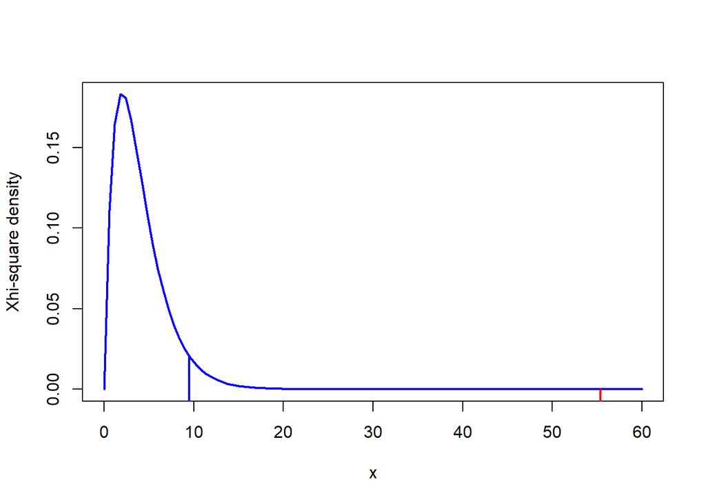

```r
> df <- length(f) - 1 - 1
> alpha <- 0.05
> curve(dchisq(x, df), from = 0, to = 60, col = "blue", lwd = 2, ylab = "Xhi-square density")
> x <- qchisq(1 - alpha, df)
> segments(x, -1, x, dchisq(x, df), col = "blue", lwd = 2)
> segments(xemp, -1, xemp, dchisq(xemp, df), col = "red", lwd = 2)
```

and conclude that the sample is in the critical area for $H_0$. Therefore, we reject $H_0$.

```r
> pchisq(xemp, df, lower.tail = FALSE)
[1] 2.718164e-11
```

The $p-value = 2.718164 * 10^{-11} < 0.05 = \alpha$, so we reject $H_0$. The distribution of the damaged sewing machines is not Poisson.

## Chi-square test for independence

Now let us study how to test independence **between the observed random variables** . In case when both random variables are numeric there are more appropriate tests. Chi-square tests for independence are usually used when at least one of the observed variables is categorical.

These test work with large sample tests as far as they use asymptotic distribution in order to determine the critical area for $H_0$.

Let us assume that we have independent observations on two random variables $X$ and $Y$. The results are summarized in the following table

| X $\backslash$ Y | Category $Y_1$ | Category $Y_2$ | … | Category $Y_c$ | Total: |
| --- | --- | --- | --- | --- | --- |
| **Category $X_1$** | $f_{11}$ | $f_{12}$ | … | $f_{1c}$ | $f_{1}^X$ |
| **Category $X_2$** | $f_{21}$ | $f_{22}$ | … | $f_{2c}$ | $f_{2}^X$ |
| **…** | … | … | … | … | … |
| **Category $X_r$** | $f_{r1}$ | $f_{r2}$ | … | $f_{rc}$ | $f_{r}^X$ |
| **Total:** | $f_{1}^Y$ | $f_{2}^Y$ | … | $f_{c}^Y$ | $n$ |

where $f_{ij}$ is the number of observations having $i$-th category of $X$ and $j$-th category of $Y$. $f_{1}^X$ is the number of observations in the first category of $X$, and so on to $f_{r}^X$. $f_{1}^Y$ is the number of observations in the first category of $Y$, and so on to $f_{c}^Y$. $n$ is the sample size. Then,
$$\sum_{i = 1}^r \sum_{j = 1}^c f_{ij} = n, \quad \sum_{j = 1}^c f_{ij} = f_{i}^X, \quad \sum_{i = 1}^r f_{ij} = f_{j}^Y.$$
If the observed $X$ and $Y$ are independent, then for all $i = 1, 2, ..., r$ and $j = 1, 2, ...., c$,
$$P(X = X_i, Y = Y_j) = P(X = X_i)P(Y = Y_j).$$
The estimator of $P(X = X_i)$ is $\frac{f_{i}^X}{n}$.

The estimator of $P(Y = Y_j)$ is $\frac{f_{j}^Y}{n}$.

Therefore, if $X$ and $Y$ are independent the expected values $e_{ij}$ would be such that
$$p_{ij} = \frac{f_{i}^X f_{j}^Y}{n^2} = \frac{e_{ij}}{n}.$$
and if we multiply by $n$ we obtain
$$e_{ij} = \frac{f_{i}^X f_{j}^Y}{n} = np_{ij}.$$
The sums in rows in the table with the expected values coincide with the corresponding one in the initial table
$$\sum_{i = 1}^r \sum_{j = 1}^c e_{ij} = n, \quad \sum_{j = 1}^c e_{ij} = f_{i}^X, \quad \sum_{i = 1}^r e_{ij} = f_{j}^Y.$$

| X $\backslash$ Y | Category $Y_1$ | Category $Y_2$ | … | Category $Y_c$ | Total: |
| --- | --- | --- | --- | --- | --- |
| **Category $X_1$** | $e_{11}$ | $e_{12}$ | … | $e_{1c}$ | $f_{1}^X$ |
| **Category $X_2$** | $e_{21}$ | $e_{22}$ | … | $e_{2c}$ | $f_{2}^X$ |
| **…** | … | … | … | … | … |
| **Category $X_r$** | $e_{r1}$ | $e_{r2}$ | … | $e_{rc}$ | $f_{r}^X$ |
| **Total:** | $f_{1}^Y$ | $f_{2}^Y$ | … | $f_{c}^Y$ | $n$ |

$H_0$ : $X$ and $Y$ are independent. More precisely for all $i = 1, 2, ..., r$ and $j = 1, 2, ...., c$,
$$P(X = X_i, Y = Y_j) = P(X = X_i)P(Y = Y_j).$$

The alternative is

$H_A$ : There exist $i = 1, 2, ..., r$ and $j = 1, 2, ...., c$ such that
$$P(X = X_i, Y = Y_j) \not= P(X = X_i)P(Y = Y_j),$$
Which is the same as $X$ and $Y$ are dependent.

We chose level of significance $\alpha$.

In this case the critical area is
$$W_\alpha = \left\{\sum_{i=1}^r\sum_{j=1}^c\frac{(f_{ij} - np_{ij})^2}{np_{ij}} \geq x_{1 - \alpha; \chi^2((r-1)(c-1))}\right\}$$

### Example 9

Explorers would like to test the hypothesis if the car belts influence the injury level. They have made a sample of $n = 86769$ independent observations and have obtained the following results

| car crush $\backslash$ Injury Level | None | Minimal | Minor | Major | Total: |
| --- | --- | --- | --- | --- | --- |
| **yes belt** | 12813 | 647 | 359 | 42 |  |
| **no belt** | 65963 | 4000 | 2642 | 303 |  |
| **Total:** |  |  |  |  |  |

Are the two variables independent? Does the seat belt make a statistically significant difference in injury levels?

One way to solve this is:

```r
> r <- 2
> c <- 4
> df <- (r - 1) * (c - 1)
```

```r
> None <- c(12813, 65963)
> Minimal <- c(647, 4000)
> Minor <- c(359, 2642)
> Major <- c(42, 303)
> car <- data.frame(None, Minimal, Minor, Major)
> row.names(car) <- c("yes belt", "no belt")
> car
          None Minimal Minor Major
yes belt 12813     647   359    42
no belt  65963    4000  2642   303
```

```r
> AllNone <- sum(car[, 1])
> AllMinimal <- sum(car[, 2])
> AllMinor <- sum(car[, 3])
> AllMajor <- sum(car[, 4])
> AllYes <- sum(car[1, ])
> AllNo <- sum(car[2, ])
> All <- sum(car)
```

```r
> f <- c(None, Minimal, Minor, Major)
> e11 <- (AllYes * AllNone) / All
> e12 <- (AllYes * AllMinimal) / All
> e13 <- (AllYes * AllMinor) / All
> e14 <- (AllYes * AllMajor) / All
> e21 <- (AllNo * AllNone) / All
> e22 <- (AllNo * AllMinimal) / All
> e23 <- (AllNo * AllMinor) / All
> e24 <- (AllNo * AllMajor) / All
> e <- c(e11, e21, e12, e22, e13, e23, e14, e24)
> Xemp <- sum((f - e)^2 / e)
> Xemp
[1] 59.22397
```

$x_{emp} = 59.22397$

$p-value$ is the probability that a chi-square statistic having $(2-1)(4-1)=3$ degrees of freedom is more extreme than $59.22397$
$$p-value = P(\eta > 59.22397), \quad \eta \in \chi^2(3)$$

```r
> pchisq(Xemp, df, lower.tail = FALSE)
[1] 8.610376e-13
```

The $p - value = 0.0000000000008610376 < 0.05 = \alpha$, so we reject $H_0$. There is a relationship between the wearing belts and injury levels.

Another way to solve this is by using the function `chisq.test`

```r
> yesbelt <- c(12813, 647, 359, 42)
> nobelt <- c(65963, 4000, 2642, 303)
> chisq.test(data.frame(yesbelt, nobelt))

    Pearson's Chi-squared test

data:  data.frame(yesbelt, nobelt)
X-squared = 59.224, df = 3, p-value = 8.61e-13
```

The $p-value = 0.000000000000861 < 0.05 = \alpha$, so we reject $H_0$. There is a relationship between the wearing belts and injury levels.

### Example 10

A government would like to test the hypothesis if gender influences the voting preferences. They have made a sample of $n = 1000$ independent observations and have obtained the following results

| Gender $\backslash$ Voting Preferences | Republican | Democrat | Independent | Total: |
| --- | --- | --- | --- | --- |
| **Male** | 200 | 150 | 50 | 400 |
| **Female** | 250 | 300 | 50 | 600 |
| **Total:** | 450 | 450 | 100 | 1000 |

Do the mens’ voting preferences differ significantly from the womens’ preferences?

$H_0$: Gender and voting preferences are independent.

$H_A$: Gender and voting preferences are not independent.

One way to solve this is:

```r
> r <- 2
> c <- 3
> df <- (r - 1) * (c - 1)
```

```r
> Republican <- c(200, 250)
> Democrat <- c(150, 300)
> Independent <- c(50, 50)
> voting <- data.frame(Republican, Democrat, Independent)
> row.names(voting) <- c("Male", "Female")
> voting
       Republican Democrat Independent
Male          200      150          50
Female        250      300          50
```

```r
> AllRepublican <- sum(voting[, 1])
> AllDemocrat <- sum(voting[, 2])
> AllIndependent <- sum(voting[, 3])
> AllMale <- sum(voting[1, ])
> AllFemale <- sum(voting[2 ,])
> All <-sum(voting)
```

```r
> f <- c(Republican, Democrat, Independent)
> e11 <- (AllMale * AllRepublican) / All
> e12 <- (AllMale * AllDemocrat) / All
> e13 <- (AllMale * AllIndependent) / All
> e21 <- (AllFemale * AllRepublican) / All
> e22 <- (AllFemale * AllDemocrat) / All
> e23 <- (AllFemale * AllIndependent) / All
> e <- c(e11, e21, e12, e22, e13, e23)
> Xemp <- sum((f - e)^2 / e)
> Xemp
[1] 16.2037
```

$x_{emp} = 16.2037$

$p-value$ is the probability that a chi-square statistic having $(2 - 1)(3 - 1) = 2$ degrees of freedom is more extreme than $16.2037$

$$P(\eta > x_{emp}) = P(\eta > 16.2037) = 0.0003029781, \quad \eta \in \chi^2(2)$$

```r
> pchisq(Xemp, df, lower.tail = FALSE)
[1] 0.0003029775
```

The $p-value = 0.0003 < 0.05 = \alpha$, so we reject $H_0$. There is a relationship between gender and voting preference.

Another way to solve this is by using function `chisq.test`

```r
> Male <- c(200, 150, 50)
> Female <- c(250, 300, 50)
> chisq.test(data.frame(Male, Female))

    Pearson's Chi-squared test

data:  data.frame(Male, Female)
X-squared = 16.204, df = 2, p-value = 0.000303
```

The $p-value = 0.000303 < 0.05 = \alpha$, so we reject $H_0$.

## Chi-square test for homogeneity

We frequently need to test if the **distributions of two populations coincides in practice**. Again the method works for any kind or random variables. However, as far as for numerical random variables there are better tests, usually they are applied for categorical random variables.

Suppose we have $m$ observations on random variables $X$ and $s$ observations on a random variable $Y$, any of them with $k$ categories. Let us denote the relative frequencies in the categories correspondingly with
$$\hat{p}_{X_1}, \,\hat{p}_{X_2}, \,...,\, \hat{p}_{X_k} \quad and \quad \hat{p}_{Y_1},\, \hat{p}_{Y_2}, \,...,\, \hat{p}_{Y_k},$$
Assume that the samples are large enough, and in any of these groups there are at least $5$ observations.

$H_0:$ $X$ and $Y$ are homogeneous, i.e. $X \stackrel{d}{=} Y$. The differences in the samples are not statistically significant.

The alternative is

$H_A$ : $X \not\stackrel{d}{=} Y$. The differences in the samples are statistically significant.

We chose $\alpha$.

$$W_\alpha = \left\{\sum_{i=1}^k\frac{(\hat{p}_{X_i} - \hat{p}_{Y_i})^2}{\frac{m\hat{p}_{X_i} + s\hat{p}_{Y_i}}{ms}} \geq x_{1 - \alpha; \chi^2(k-1)}\right\},$$

### Example 11

Let us suppose we roll two dice.

- Fair die 200 times
- Biased die 100 times

Simulate the results and apply the chi-square test for homogeneity.

```r
> set.seed(1)
> die.fair <- sample(1:6, 200, prob = c(1, 1, 1, 1, 1, 1)/6, replace = TRUE)
> set.seed(1)
> die.bias <- sample(1:6, 100, prob = c(0.5, 0.5, 1, 1, 1, 2)/6, replace = TRUE)
> fair.freq <- table(die.fair)
> bias.freq <- table(die.bias)
> freq <- rbind(fair.freq, bias.freq)
> freq
           1  2  3  4  5  6
fair.freq 32 22 34 42 36 34
bias.freq  4 10 25 13 21 27
```

```r
> chisq.test(freq)

    Pearson's Chi-squared test

data:  freq
X-squared = 16.154, df = 5, p-value = 0.006419
```

The $p-value = 0.006419 < 0.05 = \alpha$, so we reject $H_0$. Both sets of data come from different distributions.